### Input:

We have a dataset with N samples (data points) and p independent variables (features/predictor) which can be denoted as $x_{ij}$ with $i: 1 \rightarrow N$ and $j: 1 \rightarrow p$.

This can also be represented by matrix $\textbf{X}$ with $N$ rows $x_1,x_2,...,x_N$ and $p+1$ column including the $\textbf{1}$ column ($1,1,...,1$) and the $p$ columns $\mathbf{x_1},\mathbf{x_2},...,\mathbf{x_p}$

$$\textbf{X}_{N,p+1} =
\begin{array}{l|l*{4}|{c}r}
& \mathbf{x_0} & \mathbf{x_1} & \mathbf{x_2} & \mathbf{x_j} & \mathbf{x_p} \\
\hline
x_1 & 1 & x_{11} & x_{12} & \cdots & x_{1p} \\
x_2 & 1 & x_{21} & x_{22} & \cdots & x_{2p} \\
x_i & 1 & \vdots & \vdots & \ddots & \vdots \\
x_N & 1 & x_{N1} & x_{N2} & \cdots & x_{Np} \\
\end{array}$$

We also have target (dependent) variable $y_i$ , which can also be represented by vector $\textbf{y} = (y_1,y_2,...,y_N)^T$

### The idea:

Linear model assume there is linear relationship between $\textbf{y}$ and $\textbf{X}$ such as:
$$\textbf{y} = \textbf{X}\beta \quad \text{or} \quad y_i = \beta_0 + \sum_{j=1}^{p}x_{ij}\beta_j\quad \text{(the general equation)}$$
in which: vector coefficients $\beta = (\beta_0,\beta_1,...,\beta_p)^T$ represents the line that best fits the data
But it doesn’t make sense if we write equation like above unless all the point $y_i$ are on a straight line. To make the model realistic, an error term is added when we express $\textbf{y}$ in the linear form of $\textbf{X}$
$$\textbf{y} = \textbf{X}\beta + \varepsilon \quad \text{or} \quad y_i = \beta_0 + \sum_{j=1}^{p}x_{ij}\beta_j + \varepsilon_i$$
assuming that:

1. $\textbf{X}$ and $x_{ij}$ are fixed (non-random)
2. $y_i$ are uncorrelated and have a constant variance $\sigma^2$
3. random variable $\varepsilon \sim \mathcal{N}(0,\sigma^2)$

### Train the model / Estimate the coefficients:

There are many ways to estimate beta: method of ordinary least square (OLS), method of moments, method of maximum likelihood. In this case, we will use the OLS method. Denote: 1. $\hat{\textbf{y}}$ and $\hat{y_i}$ as the fitted value from the regression line 2. $\hat{\beta}$ and $\hat{\beta_j}$ as the estimated value of beta The line (with vector slope $\beta$) is the one best fits the data and the output of the model (or the predicted value) would be
$$\hat{\textbf{y}} = \textbf{X}\hat{\beta} \quad \text{or} \quad \hat{y_i} = \hat{\beta_0} + \sum_{j=1}^{p}x_{ij}\hat{\beta_j}$$

The model (the line with vector slopes $\beta$ that best fits the data) can be computed/estimated by minimizing residual sum-of-squares:
$$\text{RSS}(\beta) = (\textbf{y} - \textbf{X}\beta)^T(\textbf{y} - \textbf{X}\beta)$$
And we have the result after differentiating w.r.t $\beta$:
$$\hat{\beta} = (\textbf{X}^T\textbf{X})^{-1}\textbf{X}^T\textbf{y}$$

### Intepreting the results:

```r
crime <- read.csv("crime-data.csv", stringsAsFactors = FALSE, sep = ",")
dim(crime)
```

```
## [1] 506  14
```

```r
lin <- lm(crim ~ ., data = crime)
summary(lin)
```

```
##
## Call:
## lm(formula = crim ~ ., data = crime)
##
## Residuals:
##    Min     1Q Median     3Q    Max
## -9.924 -2.120 -0.353  1.019 75.051
##
## Coefficients:
##               Estimate Std. Error t value Pr(>|t|)
## (Intercept)  17.033228   7.234903   2.354 0.018949 *
## zn            0.044855   0.018734   2.394 0.017025 *
## indus        -0.063855   0.083407  -0.766 0.444294
## chas         -0.749134   1.180147  -0.635 0.525867
## nox         -10.313535   5.275536  -1.955 0.051152 .
## rm            0.430131   0.612830   0.702 0.483089
## age           0.001452   0.017925   0.081 0.935488
## dis          -0.987176   0.281817  -3.503 0.000502 ***
## rad           0.588209   0.088049   6.680 6.46e-11 ***
## tax          -0.003780   0.005156  -0.733 0.463793
## ptratio      -0.271081   0.186450  -1.454 0.146611
## black        -0.007538   0.003673  -2.052 0.040702 *
## lstat         0.126211   0.075725   1.667 0.096208 .
## medv         -0.198887   0.060516  -3.287 0.001087 **
## ---
## Signif. codes:  0 '***' 0.001 '**' 0.01 '*' 0.05 '.' 0.1 ' ' 1
##
## Residual standard error: 6.439 on 492 degrees of freedom
## Multiple R-squared:  0.454,  Adjusted R-squared:  0.4396
## F-statistic: 31.47 on 13 and 492 DF,  p-value: < 2.2e-16
```

1. Residuals: $\varepsilon = \textbf{y}-\hat{\textbf{y}}$ difference between predicted (or fitted) and actual value. This should be 5 point summary of a normal distribution, because $\varepsilon \sim \mathcal{N}(0,\sigma^2)$
2. Estimate: $\hat{\beta} = (\hat{\beta_0},\hat{\beta_1},...,\hat{\beta_j},...,\hat{\beta_p})$
3. Std.Error (or S): (standard error = standard deviation of a statistic of the data) standard deviation of the betas: $\hat{\sigma_j} = \sqrt{\text{Var}(\hat{\beta_j})}$ with $j:1\rightarrow p$
   Noted that
   $$\hat{\beta} \sim \mathcal{N}(\beta,(\textbf{X}^T\textbf{X})^{-1}\sigma^2)$$
   (Hastie, Trevor page 66 eq 3.10)

for a simple linear regression model, where $\beta = (\beta_0,\beta_1)^T$
$$\text{Var}(\beta_1) = \frac{\sigma^2}{\sum_{i=1}^{N}(x_i-\bar{x})^2} =
\frac{\sum_{i=1}^{N}(y_i-\hat{y}_i)^2}{(N-1-1)\sum_{i=1}^{N}(x_i-\bar{x})^2}$$
(wikipedia-ols, Unbiasedness and variance of betas)

4. t-value: $t_j=\hat{\beta_j}/\hat{\sigma_j}$ or in matrix representation $t = \hat{\beta}/\sqrt{\text{Cov}(\hat{\beta})}$ This is the standardized variables of $\hat{\beta}_j$ (similar to z-score)

```r
tstats = coef(lin)/ sqrt(diag(vcov(lin)))
summary(lin)$coefficients[,3] # equivalent to above
```

```
## (Intercept)          zn       indus        chas         nox          rm
##  2.35431317  2.39431224 -0.76557890 -0.63478004 -1.95497373  0.70187538
##         age         dis         rad         tax     ptratio       black
##  0.08098372 -3.50289299  6.68044796 -0.73318838 -1.45390099 -2.05195893
##       lstat        medv
##  1.66671043 -3.28651687
```

t-stats vs z-score: - t-stats (t-distribution): used when unknown population variance, insufficiently samples ($N < 30$) (in which t-distribution become same as standard normal distribution) - z-score (normal distribution): used when known population variance, large samples ($N > 30$) (in which t-distribution become same as standard normal distribution) 5. Pr(>|t|): p-value - Null hypothesis: $H_0$: $\beta_j = 0$ or t-value = 0 - Input: t-stats as the support (horizontal axe) of the t-distribution - Output: probability, CDF, of returning number with greater absolute value than that of the t-stats (smaller in lower tail and greater in upper tail)

http://www.statisticshowto.com/probability-and-statistics/hypothesis-testing/t-score-vs-z-score/

https://math.stackexchange.com/questions/1350635/when-do-i-use-a-z-score-vs-a-t-score-for-confidence-intervals

```r
2 * pt(abs(tstats), df = df.residual(lin), lower.tail = FALSE)
```

```
##  (Intercept)           zn        indus         chas          nox
## 1.894909e-02 1.702489e-02 4.442940e-01 5.258670e-01 5.115200e-02
##           rm          age          dis          rad          tax
## 4.830888e-01 9.354878e-01 5.022039e-04 6.460451e-11 4.637927e-01
##      ptratio        black        lstat         medv
## 1.466113e-01 4.070233e-02 9.620842e-02 1.086810e-03
```

```r
#summary(lin)$coefficients[,4]
```

- So we compute the upper tail probability of achieving the $t$ values we did from a $t$ distribution with degrees of freedom equal to the residual degrees of freedom of the model. This represents the probability of achieving a $t$ value greater than the absolute values of the observed $t$s. It is multiplied by 2, because of course $t$ can be large in the negative direction too. (Gavin Simpson)
- t-distributions are defined by the DF (degree of freedom) - sample size
- **Intepretation**: The smaller the p-value (more significant), the greater the distance from the t-statistics (the $\beta_j$ likewise) to 0 (the t-distribution mean) - the more explanatory power of the feature
- **Intepretation**: We should omit variables with large (insignificant) p-value
- Why don’t use the $\beta_j$ directly but use the t-stats ? A: need to adjust for its variance
6. Residual standard error: $\sigma$ (noted that $\varepsilon \sim \mathcal{N}(0,\sigma^2)$) (standard error = standard deviation of a statistic of the data) standard deviation of the residuals
- Typically one estimate the variance $\sigma^2$ by
  $$\hat{\sigma}^2 = \frac{1}{N-p-1} \sum_{i=1}^{N}(y_i-\hat{y}_i)^2$$
  (Hastie, Trevor page 66 eq 3.8)
- Also
  $$(N-p-1)\hat{\sigma}^2 \sim \sigma^2\mathcal{X}_{N-p-1}^2$$
  (Hastie, Trevor page 66 eq 3.11) a chi-squared distribution with $N-p-1$ degrees of freedom.

More at (wikipedia-ols, Expected value of sigma & Maximum likelihood approach)

- **Interpretation**: to assess the precision. the smaller the better. It (smaller value) also indicates that the observations are closer to the fitted line.
7. Multiple R-squared:
- $\bar{y} = \frac{1}{N}\sum_{i=1}^{N}y_i$
- Total sum of squares (proportional to the variance of the data) *(actual value vs mean)*
  $$TSS = SS_{tot} = \sum_i(y_i-\bar{y})^2$$
- The regression sum of squares, or explained sum of squares *(regression fitted value vs mean)*
  $$ESS = SS_{reg} = \sum_i(\hat{y_i}-\bar{y})^2$$
- The sum of squares of residuals/error of prediction *(actual vs fitted)*
  $$RSS = SS_{res} = \sum_i(y_i-\hat{y_i})^2 = \sum_i\varepsilon_i^2$$
  $$RSS = SS_{res} = (\textbf{y} - \textbf{X}\hat\beta)^T(\textbf{y} - \textbf{X}\hat\beta) = \hat\varepsilon^t\hat\varepsilon = \left\Vert\varepsilon\right\Vert^2$$
- R-square (coefficient of determination) *(1 - residual/ sth)*
  $$R^2 = 1 - \frac{SS_{res}}{SS_{tot}}
  = 1 - \frac{\sum_i(y_i-\hat{y_i})^2}{\sum_i(y_i-\bar{y})^2}$$
- We have
  $$TSS = RSS + ESS - 2\textbf{y}^T\bar{y} + 2\mathbf{\hat{y}}^T\bar{y}$$
  https://en.wikipedia.org/wiki/Explained_sum_of_squares#Partitioning_in_the_general_OLS_model
- Relation $TSS = RSS + ESS$ if and only if:
- $\textbf{y}^T\bar{y} = \mathbf{\hat{y}}^T\bar{y}$ or equivalently $\sum_i(y_i-\hat{y_i}) = \sum_i\varepsilon_i = 0$
- Always hold true with simple linear regression where $\beta = (\beta_0,\beta_1)^T$
- **Interpretation**: Basically, if residuals sum of squares smaller , the closer $R^2$ to 1, the better he linear regression fit the data
- For R-squared, you want the regression model to explain higher percentages of the variance. Higher R-squared values indicate that the data points are closer to the fitted values
- Key Limitations of R-squared:
- R-squared cannot determine whether the coefficient estimates and predictions are biased.
- R-squared does not indicate whether a regression model is adequate. You can have a low R-squared value for a good model, or a high R-squared value for a model that does not fit the data!
- While higher R-squared values are good, they don’t tell you how far the data points are from the regression line. Additionally, R-squared is valid for only linear models.
- Low R-squared: not really bad
- statistically significant predictors can draw important conclusion
- High R-square: needed for prediction. However, not really good. Example: http://blog.minitab.com/blog/adventures-in-statistics-2/regression-analysis-how-do-i-interpret-r-squared-and-assess-the-goodness-of-fit
- You might be overfitting your model Ned to check residual plot also !
8. Adjusted R-squared: is computed as
   $$1 - (1 - R^2) \frac{n-1}{n-p-1}$$
   The adjusted $R^2$ is the same thing as $R^2$, but adjusted for the complexity (i.e. the number of parameters) of the model. Given a model with a single parameter, with a certain $R^2$, if we add another parameter to this model, the $R^2$ of the new model has to increase, even if the added parameter has no statistical power. The adjusted $R^2$ accounts for this by including the number of parameters in the model. (Gavin Simpson)
9. F-statistic: F-test of overall significance
   $$F = \frac{(RSS_0 - RSS_1)/(p_1-p_0)}{RSS_1/(N-p-1)}$$
   (Hastie, Trevor eq 3.13 page 67) The hypotheses for the F-test of the overall significance are as follows:
- Null hypothesis: The fit of the intercept-only model and your model are equal.
- Alternative hypothesis: The fit of the intercept-only model is significantly reduced compared to your model.

Note: F-distribution has 2 parameters: df1 and df2 If the P value for the F-test of overall significance test is less than your significance level, you can reject the null-hypothesis and conclude that your model provides a better fit than the intercept-only model. In this case, the regression model predicts the response variable better than the mean of the response.

http://blog.minitab.com/blog/adventures-in-statistics-2/what-is-the-f-test-of-overall-significance-in-regression-analysis 10. Confidence intervals (of the estimates) (The distance equals the critical t-value * standard error of the mean)

```r
confint(lin,colnames(crime)[-1],level = 0.95)
```

```
##                 2.5 %        97.5 %
## zn        0.008046562  0.0816638671
## indus    -0.227733150  0.1000235023
## chas     -3.067882868  1.5696156471
## nox     -20.678894713  0.0518248891
## rm       -0.773956866  1.6342178774
## age      -0.033767600  0.0366708869
## dis      -1.540889544 -0.4334619069
## rad       0.415209611  0.7612075719
## tax      -0.013909700  0.0063496670
## ptratio  -0.637417996  0.0952568794
## black    -0.014754837 -0.0003201725
## lstat    -0.022572584  0.2749953365
## medv     -0.317788478 -0.0799851646
```

https://onlinecourses.science.psu.edu/stat414/node/280

- **Interpretation**: If the confidence interval does not contain the null hypothesis value, the results are statistically significant.
11. Residual plot

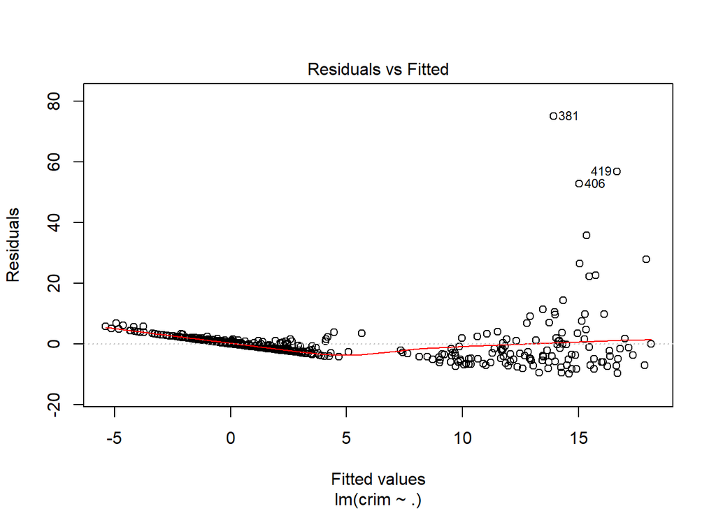

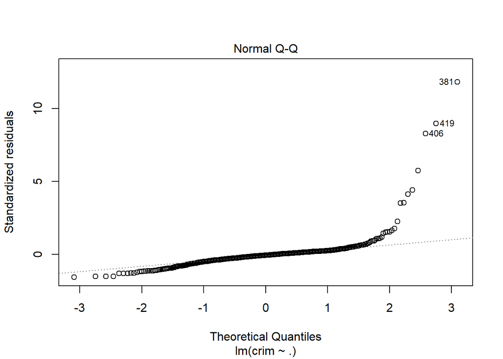

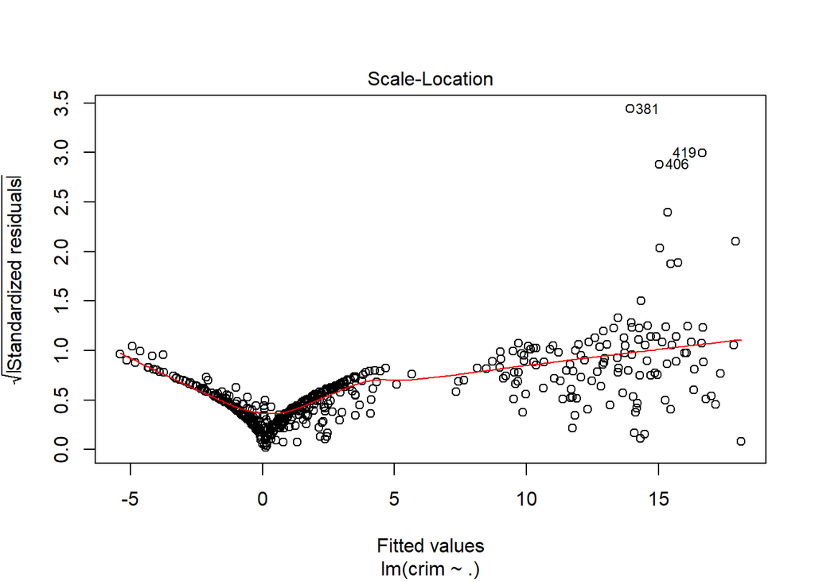

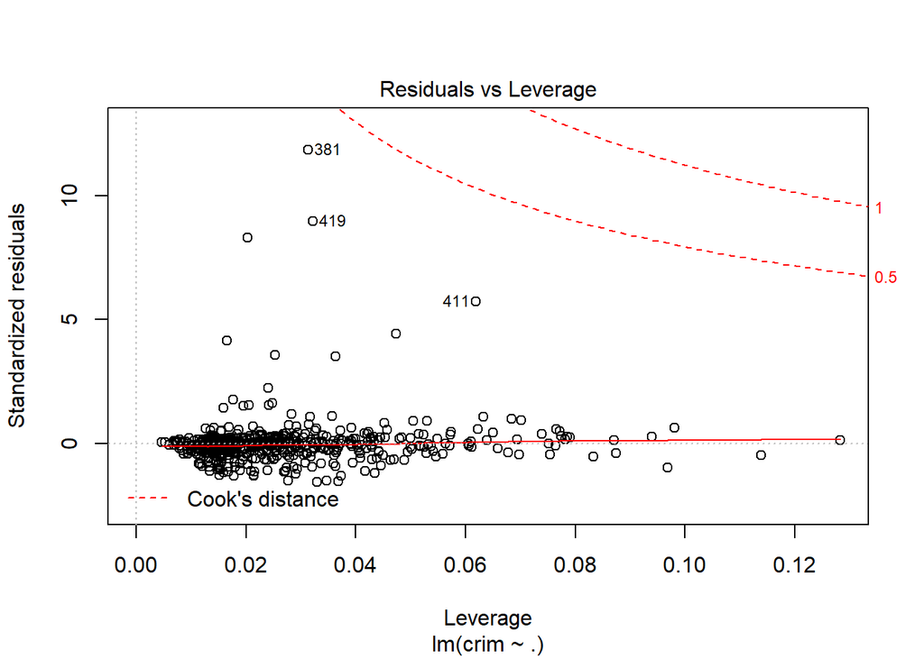

```r
plot(lin)
```

Ideally residual plot should be (1) they’re pretty symmetrically distributed, tending to cluster towards the middle of the plot (2) they’re clustered around the lower single digits of the y-axis (e.g., 0.5 or 1.5, not 30 or 150) (3) in general there aren’t clear patterns (statwing)

It seems that in this case there is a pattern in the residual plot: residuals tend to be negative when fitted values range from 0 to 10

The non-random pattern in the residuals indicates that the deterministic portion (predictor variables) of the model is not capturing some explanatory information that is “leaking” into the residuals. Possibilities include:

- A missing variable
- A missing higher-order term of a variable in the model to explain the curvature
- A missing interaction between terms already in the model (minitab)
12. ANOVA

```r
anova(lin)
```

```
## Analysis of Variance Table
##
## Response: crim
##            Df  Sum Sq Mean Sq  F value    Pr(>F)
## zn          1  1501.5  1501.5  36.2140 3.457e-09 ***
## indus       1  4689.3  4689.3 113.0959 < 2.2e-16 ***
## chas        1   247.8   247.8   5.9761 0.0148509 *
## nox         1  1270.8  1270.8  30.6476 5.041e-08 ***
## rm          1   138.5   138.5   3.3406 0.0681959 .
## age         1   165.5   165.5   3.9916 0.0462773 *
## dis         1   300.1   300.1   7.2372 0.0073834 **
## rad         1  7238.3  7238.3 174.5724 < 2.2e-16 ***
## tax         1     3.3     3.3   0.0798 0.7776270
## ptratio     1     7.3     7.3   0.1756 0.6753646
## black       1   455.3   455.3  10.9798 0.0009890 ***
## lstat       1   497.7   497.7  12.0042 0.0005772 ***
## medv        1   447.9   447.9  10.8012 0.0010868 **
## Residuals 492 20399.9    41.5
## ---
## Signif. codes:  0 '***' 0.001 '**' 0.01 '*' 0.05 '.' 0.1 ' ' 1
```

### Additional material:

http://blog.minitab.com/blog/adventures-in-statistics-2/regression-analysis-tutorial-and-examples  
http://reliawiki.org/index.php/Simple_Linear_Regression_Analysis

### References:

Gavin Simpson. “Interpretation-of-Rs-Lm-Output.” *Stackoflow*. https://stats.stackexchange.com/questions/5135/interpretation-of-rs-lm-output.

Hastie, Trevor, Tibshirani. “The Elements of Statistical Learning.” https://web.stanford.edu/~hastie/Papers/ESLII.pdf.

minitab. “Interpretation-of-Residual-Plot.” *Minitab*. http://blog.minitab.com/blog/adventures-in-statistics-2/why-you-need-to-check-your-residual-plots-for-regression-analysis.

statwing. “Interpretation-of-Residual-Plot.” *Statwing*. http://docs.statwing.com/interpreting-residual-plots-to-improve-your-regression/.

wikipedia-ols. “Proofs Involving Ordinary Least Squares.” *Wikipedia1*. https://en.wikipedia.org/wiki/Proofs_involving_ordinary_least_squares.